# ki Sprint 7C report out

Jade Benjamin-Chung

6/5/2018

## Background detail

**Stunting is Common in LMICs**

Stunting (height-for-age Z < -2) by age 24 months is common in LMICs and is associated with a range of poor outcomes later in life. Linear growth is thought to be a cumulative marker of a range of nutritional and infectious insults during the first 1000 days.

**Research Efforts to-date**

There is an abundance of cross-sectional research that has focused on the geographic distribution of stunting and characteristics associated with it (e.g., through demographic and health surveys). Although it is assumed that stunting prevalence is a reasonable approximation of cumulative incidence, to our knowledge this has not been verified though large-scale studies across diverse cohorts. Effects of WASH and nutritional interventions have heretofore been null or modest, and far from sufficient to address the majority of stunting in many lower-income populations.

## Motivation

The unprecedented collection and standardization of individual participant data on GHAP provides a unique opportunity to summarize broad patterns in stunting and characteristics most strongly associated with it. Individual participant data from randomized nutritional intervention trials provides the unique opportunity to examine effect modification, which would not be possible in standard meta-analyses based on aggregate effect estimates.

## Dataset list

- CMC Vellore Birth Cohort 2002
- CMIN: Child Malnutrition and Infection Network
- COHORTS (Guatemala, Philippines, India): Consortium of Health-Orientated Research in Transitioning Societies
- CONTENT: Evaluation and Control of Neglected Mucosal Enteric Infections in Childhood
- EE: Study of Biomarkers for Environmental Enteropathy
- GMS-Nepal: Growth Monitoring Study, Nepal
- GBSC: Longitudinal study of BSC in Guatemala
- iLiNS-Zinc Study: Effect of small-quantity Lipid-based Nutrient Supplements on growth, stunting, and wasting in young children: cluster-randomized trial
- IRC: Vellore Crypto Study - Birth cohort study of Cryptosporidium infection in children
- JiVitA-3 Study: Impact of antenatal multiple micronutrient supplementation on infant mortality
- JiVitA-4 Study: Effect of fortified complementary food supplementation on child growth in rural Bangladesh: a cluster-randomized trial
- MRC Kenaba: Longitudinal evaluation of the causal link between nutritional intake, physical and cognitive growth and development, and health
- LCN5: Lungwena Child Nutrition Intervention Study 5 - A single-centre, randomised, single-blind, parallel group clinical trial in rural Malawi, testing the growth promoting effect of long-term complementary feeding of infants with a high-energy, micronutrient fortified spread
- MAL-ED Study (Bangladesh, India, Nepal, Peru, South Africa, Tanzania): Global study of enteropathy and its effects on anthropometry from birth through age 2 years
- NIH Birth: NIH-Birth Cohort Study
- NIH-Crypto: Bangladesh NIH Cryptosporidium Cohort Study
- PROBIT Study: Promotion of Breast Feeding Interventional Trial
- PROVIDE Study: Performance of Rotavirus and Oral Polio Vaccines in Developing Countries
- Respak: Respiratory Pathogens Birth Cohort - Characterization of endemic respiratory pathogens in urban pregnant women and newborns
- SAS-CompFeed: Cluster randomized trial of the promotion of optimal complementary feeding practices
- SAS-FoodSuppl: Randomized trial: effect of feeding a food supplement to infants on weight gain
- Tanzania Child 2: Zinc and micronutrients
- ZVITAMBO: Study of a Single Dose of Vitamin A to Prevent Vertical and Horizontal Transmission of HIV

## Data description

### Cohort inclusion criteria:

- Studies that could contribute to the analysis include all longitudinal cohorts with anthropometric measurements that have contributed individual participant data to GHAP. From the set of 86 longitudinal cohorts, those will be eligible for inclusion in the stunting analyses if they meet the following criteria:
1. Were conducted in low- or middle-income countries
   - Rationale: target population for inference
2. Measured length between birth and age 24 months
   - Rationale: target population for inference (first 1000 days)
3. Did not restrict enrollment to acutely ill children (e.g., only children presenting to hospital with acute diarrhea).
   - Rationale: We are interested in descriptive analyses of the general population and not only children in specific subgroups.
4. Enrolled at least 200 children
   - Rationale: Stunting incidence is sufficiently rare that we want to ensure we have sufficient information to estimate it within each individual cohort.
5. Collected anthropometry measurements at least every 3 months (descriptive analyses).
   - Rationale: We are interested in describing whether the incidence and prevalence over the course of the first two years of life differs at these different time points.

Note: For objective 2, we originally planned to include studies with measurement every 6 months in the risk factor analyses, but results in this report out only include studies with measurement at least every 3 months.

## Outcome variables

- Point prevalence of stunting
- Cumulative incidence of stunting
- Stunting incidence rate
- Mean age of stunting onset
- Stunting recovery (“catch up growth”)
- Stunting duration

## Predictor Variables

We included a broad set of individual-, maternal-, and household-level characteristics. Many characteristics do not change over time and are static – those that do change over time are marked with an asterisk (*).

**Child characteristics**

- Sex
- Gestational age
- Calendar month of birth
- Birth weight (make sure this is taken at =<72 h or =<48 h or some such criteria)
- Birth order
- Delivery location
- Delivery method (C-section vs. live birth)
- Stunted at study enrollment or birth

**Maternal characteristics**

- Weight
- Height
- Age
- Education
- Unmarried
- Breast or bottle feeding
- Total duration of breastfeeding
- Maternal BMI (measured prior to pregnancy)

**Paternal characteristics**

- Age
- Education
- Height
- BMI

**Household characteristics**

- Asset based wealth index
- USAID Household Food Insecurity Access Scale (HFIAS) category or FANTA scale
- Floor/Roof material
- Drinking water treatment
- Number of children <5 in the household
- Number of individuals in the household
- Number of rooms in household

**Other characteristics**

- Calendar month of measurement (seasonality)*

**Exposures that we plan to include in Sprint 7D**

We excluded the following exposures from the current sprint and plan to include them in Sprint 7D. In the initial covariate coding using a unified set of rules for defining improved sanitation or safe water, some studies had an unrealistically high or low prevalence of WASH indicators. Additional time is needed to assess if this is a limitation of the contributed data, or to see if we need study-specific rules or to check the raw contributed data for additional informative variables. For breastfeeding practice indicators, we are still working with Vishak and his team to find the right set of variables that balance having enough information to code indicators of recommended practice with sufficient frequency of measurement across studies. We expect that we can finalize these variables to include in the adjusted exposure analysis in June/July.

- Improved sanitation (WHO Joint Monitoring program definition)
- Improved water source (WHO Joint Monitoring program definition)
- Breastfeeding frequency, exclusivity, and early initiation
- Current or recent diarrhea
- Cumulative days of diarrhea (longitudinal prevalence) *

## Methods

- We calculated point prevalence, cumulative incidence, and incidence rates within additional age strata at 3 and 9 months. We are also presenting cohort-specific results for these outcomes.
- We calculated recovery from stunting at different ages and compared LAZ at the onset of stunting and the onset of recovery.

## Methods detail

### Outcome definitions

**Mean age of stunting onset** will be defined as the mean age in days at the time of each child’s first measurement of LAZ < -2. Only children with an incident episode of stunting prior to age 24 months will be included in this measurement. We will estimate this within monthly cohorts.

**Stunting duration** will be estimated by counting the whole months between the first measurement of LAZ < -2 and the first measurement of LAZ $\geq$ -2 within an individual child among children who were stunted prior to age 24 months. We will only measure this outcome in studies with at least monthly measurement to reduce measurement error from interval censoring.

### Exposure analyses

We categorized continuous exposures using two methods. For exposures with pre-established standard categories, we defined categories using those standards (e.g., BMI, birthweight). For socioeconomic variables with absolute values that may vary substantially between countries, we defined variables based on country-specific quartiles of the observed distributions (e.g., household wealth).

We will estimated cohort-specific and pooled prevalence ratios (PRs) and cumulative incidence ratios (CIRs) using random effects models fit with restricted maximum likelihood estimation. Unadjusted PRs and CIRs between the reference level of each exposure and comparison levels were estimated using targeted maximum likelihood estimation. This report presents unadjusted bivariate analyses; we will conduct analyses adjusting for covariates in a future sprint. We estimated influence curve-based, clustered standard errors to account for repeated measures assuming that the children were the independent units of analysis.

## Results detail

### Objective 1: Descriptive epidemiology of linear growth faltering stunting

#### 1a. Point prevalence - pooled (Update from Sprint 7B)

We updated the pooled point prevalence to stratify by additional age groups (3 and 9 months). The overall pattern is the same as we reported in the last sprint – point prevalence increases steadily and plateaus at 18-24 months.

[figure not shown]

#### 1a. Point prevalence - stratified by study (Update from Sprint 7B)

The point prevalence stratified by study cohort reveal similar patterns overall. In a few studies, the point prevalence stays relatively flat from birth to 24 months, but overall there are increases in point prevalence by age until 18-24 months. Patterns were similar across geographic region.

[figure not shown]

#### 1a. Cumulative incidence - pooled (Update from Sprint 7B)

[figure not shown]

#### 1a. Cumulative incidence - stratified by study (Update from Sprint 7B)

The cumulative incidence stratified by study cohort reveal similar patterns overall with cumulative incidence increasing steadily between birth and 24 months. The cumulative incidence was higher across all ages in most studies conducted in Asia compared to other regions.

[figure not shown]

#### 1a. Incidence rate - pooled (Update from Sprint 7B)

We updated the pooled incidence rate to stratify by age 3 months in addition to the previous age groups. In this new stratification, the pooled incidence rate is now highest in the age range from 2 days to 3 months and is relatively flat from 3-24 months. These results suggest that the first three months rather than the first six months may be the critical window for intervention rather than the period up to six months as we discussed in our last report out.

[figure not shown]

#### 1a. Incidence rate - stratified by study (Update from Sprint 7B)

Cohort-specific incidence rates reveal similar patterns in some studies and a pattern of more consistent incidence rates in other studies. The incidence rates in studies conducted in Asia were higher across all ages and were particularly high in the 2 day to 3 month window, reaching incidence rates as high as 17 per 1,000 child-days in the EE-Pakistan study.

[figure not shown]

#### 1a. What is the mean age of stunting onset?

The plots below show the pooled and cohort-specific distributions of the age of stunting onset. Pooling across studies, the mean age of onset was 6.4 months and the median was 4.9 months. However, the largest number of children experienced stunting onset between 0-3 months, consistent with our age-specific incidence rate estimates.

[figure not shown]

#### 1b. Catch up growth: What is the mean number of stunting+recovery events a child has between birth and 24 months?

[figure not shown]

#### 1b. Catch up growth: What proportion of children stunted by specific ages recover within 3 months?

- What proportion of children stunted at birth were no longer stunted at 3 months?
- What proportion of children stunted at 3 months were no longer stunted at 6 months?
- What proportion of children stunted at 6 months were no longer stunted at 9 months?
- What proportion of children stunted at 9 months were no longer stunted at 12 months?

We defined a new stunted episode using 2 consecutive LAZ measurements < -2 and a recovery episode as 2 consecutive LAZ measurements > -2. This figure shows the percentage of children who were stunted at the beginning of an age interval who recovered by the end of the interval. We including any stunting episode (not just the first episode). The percentage who recovered from stunting was 14% from 0-3 and 3-6 months; the percentage who recovered dropped to 8% between 6-9 months and 5% between 9-12 months. This suggests that children who become stunted at younger ages are slightly more likely to recover, but overall the proportion of children who recover is low and recovery becomes progessively less likely as children age.

[figure not shown]

#### 1b. Catch up growth: Cohort-specific results: What proportion of children stunted by specific ages recover within 3 months?

When we stratified recovery by cohort, the patterns were similar overall with a higher percentage of children who recover earlier in life.

[figure not shown]

#### 1b. Catch up growth: What is the proportion of children who were ever stunted within the first 2 years of life, who are not stunted by 24 mo of age? (can we also look at beyond 24 mo?)

We chose to focus on recovery from stunting by age 24 months because the number of observations was quite a bit lower at older ages (N measurements at 24 months=186,892, at 36 months=19,783, at 48 months=4,646, and at 60 months=1,531).

We estimated the proportion of children who were no longer stunted by age 24 months among children who became stunted at any age before 24 months. Pooling across studies, 9% of children who became stunted before 24 months were no longer stunted at 24 months. When stratifying by cohort, this percentage ranged from 4% to 19%.

[figure not shown]

#### 1b. Catch up growth: Among those who recover from stunting by 24 months, what is the mean duration of time that they were stunted (estimated only in cohorts with at least monthly length measurement)?

To estimate the duration of stunting for children who experienced stunting and recovered, we subset the data to studies with monthly measurement. We rounded the duration to whole months to partially reduce the impact of censoring. The duration was one month for one third of children, two months for 15% of children, and 3 months for 11% of children. For about 5% of children, the duration rounded to zero because the child’s measurements at the start and end of the stunting period were within the same month. These results suggest among children who recover from stunting by 24 months, the majority have relatively short episodes of stunting between 1 and 4 months in duration.

We note that estimates of mean duration are only among the small minority of children who recover by age 24 months (9% of stunted children over all cohorts). Estimates of mean duration do not include the 91% of stunted children who did not recover by age 24 months.

[figure not shown]

#### 1b. Catch up growth: Among children who recover from stunting, what is the distribution of LAZ upon recovery?

For the majority of children, their first LAZ measurement at the onset of stunting was between -2 and -2.5 and their first LAZ measurement at the onset of recovery was between -1.5 and -2. These distributions suggest that changes to LAZ are incremental. The plot for the distribution upon recovery also reveals that many children not classified as stunted have an LAZ<0 and may have poor nutritional status even though they are not classified as stunted.

Taken together, the distribution of LAZ scores among children who are stunted and who recover is consistent with an overall continuous distribution of LAZ, where -2 is simply a cutoff within that distribution.

[figure not shown]

### Objective 2: Individual, Maternal, and Household-level Characteristics associated with Stunting

#### Objective 2a. Relative risks for age-specific cumulative incidence

**Child characteristics**

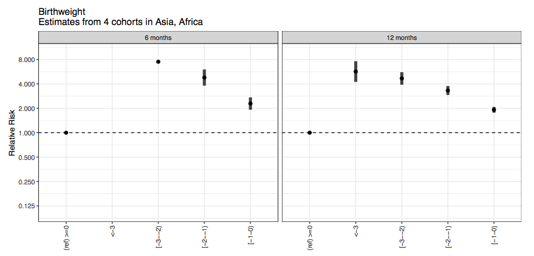

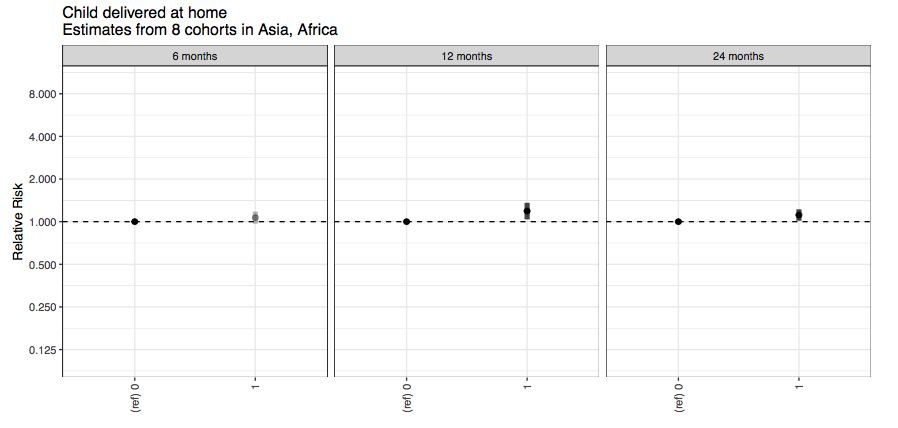

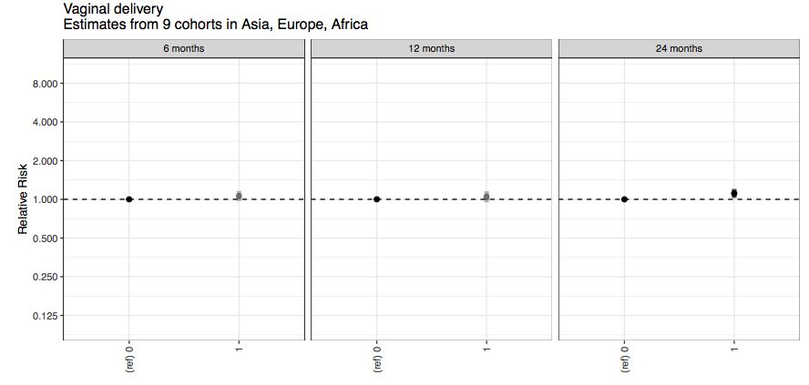

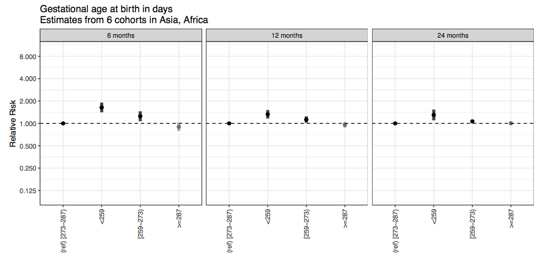

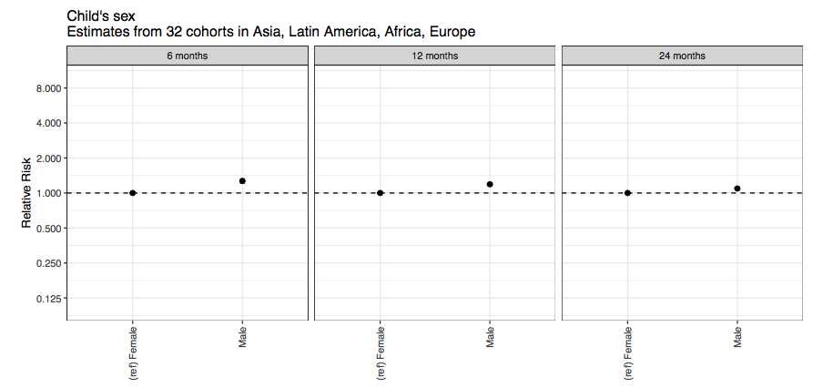

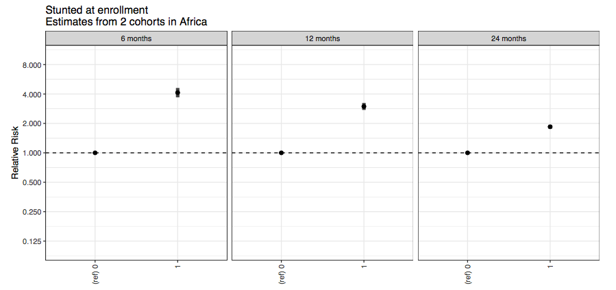

**Maternal characteristics**

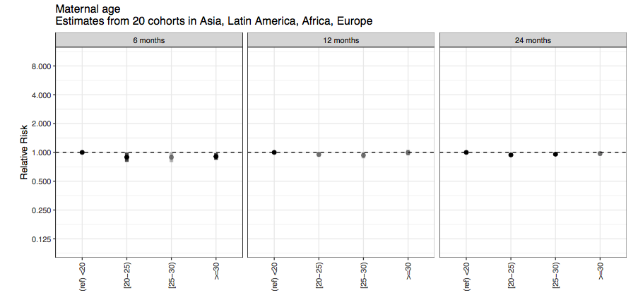

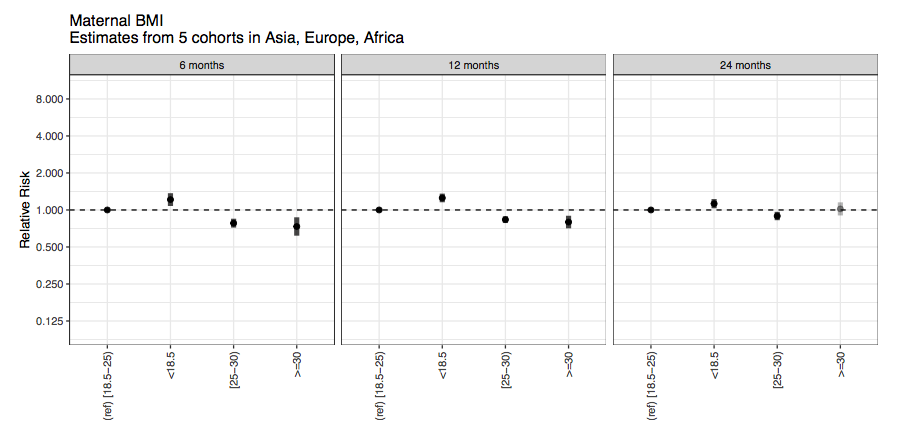

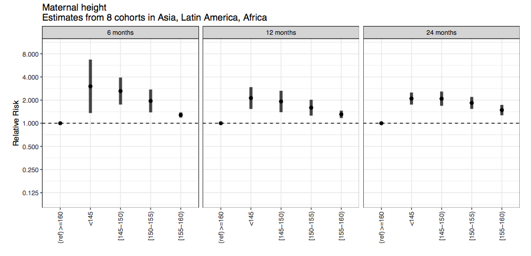

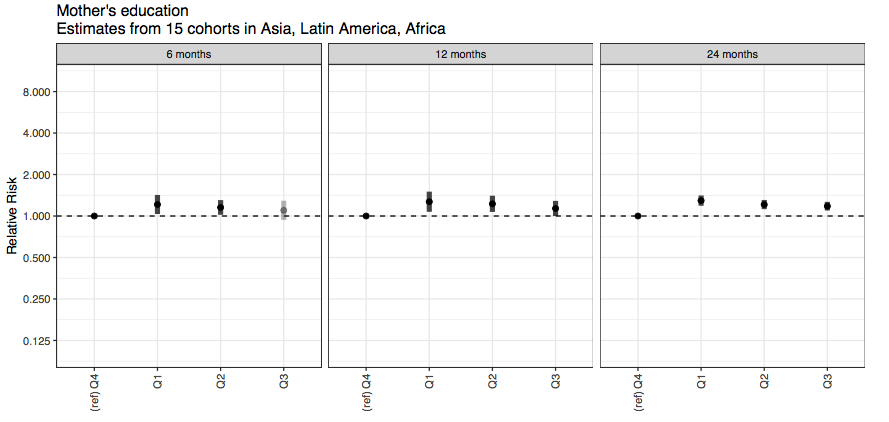

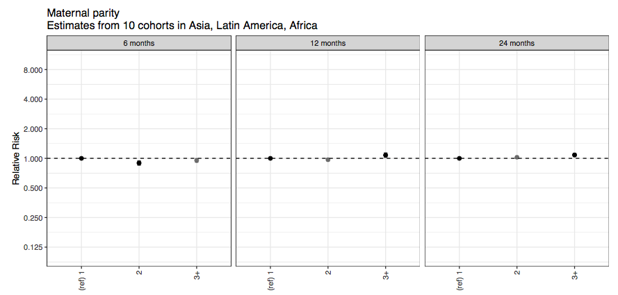

**Household characteristics**

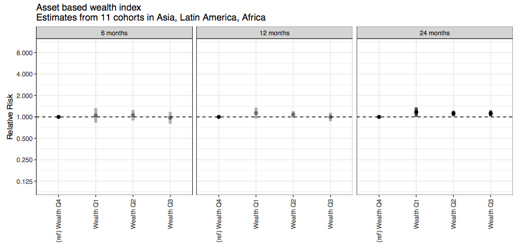

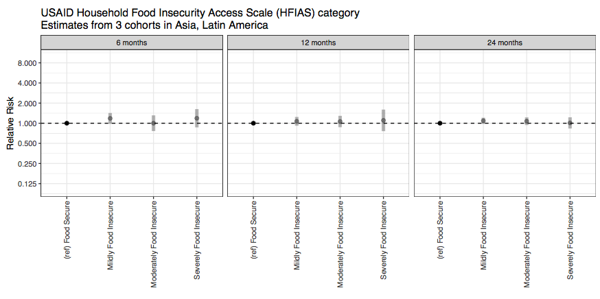

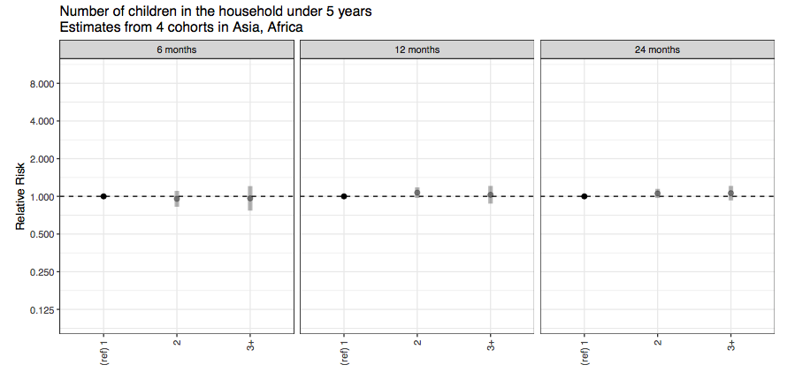

## Next steps

- Growth velocity (Objective 1c, 2c, and 3c)
- Adjusted risk factor analysis and risk factor modifiers (Objective 2e)
- Intervention effects (Objective 3)

## Data scientist assessment

We are able to complete this work successfully and especially appreciate Vishak’s team’s help preparing the covariate dataset for this analysis.